# Text Mining and Social Media Mining Project

#### 16 topics

Let’s check out the breakdown of the 16 topics.

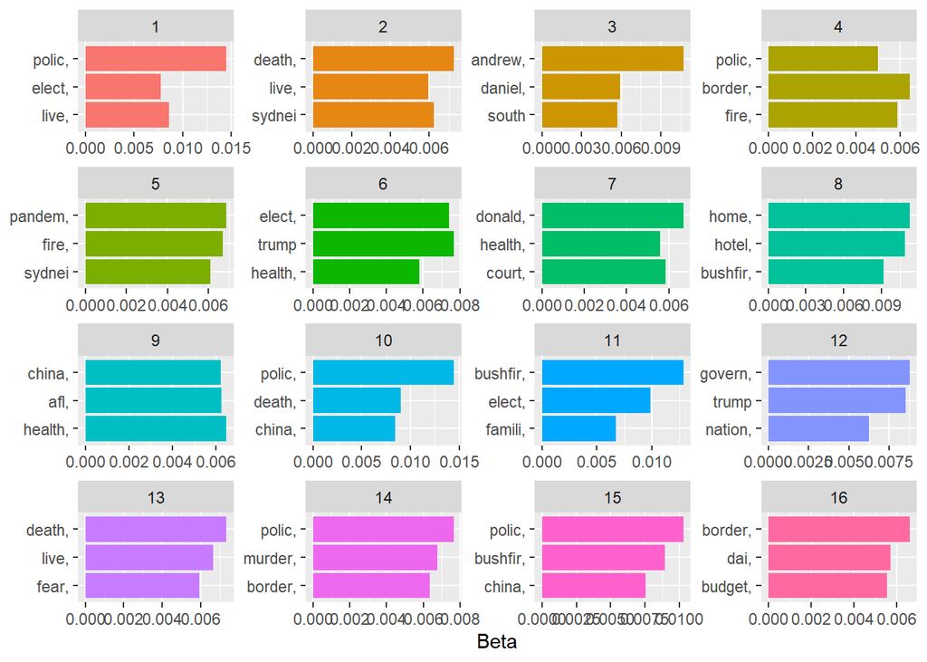

```r
# now let's look at the new most informative terms
top_terms_by_topic_LDA(cleaned_documents_2020$terms, number_of_topics = 16)
```

The naming of the topics created by the 16 division is even less clear-cut than that of the 8 division. Nevertheless, we distinguish such topics as:

- 1. **current information on election results**
- 2. **reports on deaths in Sydney**
- 4. **fires crossing the (state) border**
- 6. **health in the context of the US election**
- 8. **fire danger to buildings**
- 10. **COVID policy in China**
- 13. **fear of death**

The remaining topics are not identified.

### Conclusions

In this section, we conducted Topic Modeling for 2020. Identifying topics proved to be a difficult challenge. We believe that (as with the analysis for 2004) this was influenced by the length of the texts analyzed (no longer than 10 words, mostly 6 words)

We identified the following topics:

- **reports on COVID**
- **elections in the United States**
- **bushfires**

The topics overlap with those identified by clustering.

# Final Conclusions

In this project, we used news headline data for 2004 and 2020 to perform text clustering and topic modeling. We used Elbow and Silhouette methods to identify the optimal number of clusters and compared the results with an arbitrary number of clusters. We showed the results in the graphs.

For both the 2004 and 2020 analysis, clustering with an arbitrarily chosen number of clusters turned out to be better. The topics identified by Text Clustering and Topic Modeling were similar and consistent.

For 2004, we identified the following topics:

- **judiciary**
- **Iraq war politics**
- **politics**
- **elections**
- **general topics related to police intervention**

For 2020, we identified the following themes:

- **court rulings on new panemic regulations**
- **new restrictions introduced by the government**
- **new responsibilities of the police**
- **reports on COVID**
- **elections in the United States**
- **bushfires**

We also note that it was not always possible to identify a topic. We point to problematic input in the form of very short texts (maximum 10 words) as the reason. For this reason, we did not have enough words per text to be able to uniquely identify some topics.